# PCA con variables ordinales

Stephane Keil, Alain Cabrera y Rodrigo Murillo

**Alain Cabrera**

**Rodrigo Murillo**

**Stephane Keil**

El análisis de componentes principales parte de la matriz de correlaciones de las variables. El problema radica cuando, en el conjunto de variables, se contienen variables ordinales pues es necesario calcular las correlaciones entre dichas variables y correlaciones de las variables continuas con ellas.

A continuación se presentan alternativas para calcular dichas correlaciones. Para el caso de dos variables ordinales usaremos el *Polychoric Correlation Coefficient* y para calcular la correlación entre una variable ordinal y una continua se utilizará el *Polyserial Correlation Coefficient*.

Estos métodos están implementados en el paquete en el paquete **psych** de **R**.

## Polychoric Correlation Coefficient

La correlación *polychoric* es una técnica que permite estimar la correlación entre pares variables latentes (normalmente distribuida) que correspondan a dos variables ordinales. En el caso particular de que las variables seas dicotómicas entonces se le conoce con el nombre de correlación *tetrachoric*.

A continuación se muestra el cálculo para el caso particular de una variable dicotómica. En la siguiente elipse se muestra la distribución conjunta de un evento desde la perspectiva de dos jueces ($Y_{1}$ y $Y_{2}$) y las tolerancias $t_{1}, t_{2}$.

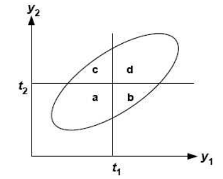

Los valores de $a, b, c$ y $d$ corresponden a la proporción de casos que caen en cada una de los casos mostrados en la elipse.

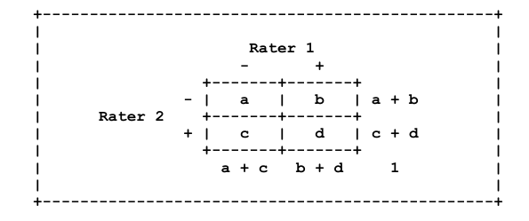

Por lo que sólo es necesario estimar el modelo representado por la elipse para encontrar los puntos de $t_{1}$ y $t_{2}$ así como el parámetro $\rho$ (rho) que determina la forma de la elipse. La forma en que se calcula dicha correlación es encontrando la cambinación de $t_{1}, t_{2}$ y $\rho$ que hacen que las proporciones de $a, b, c$ y $d$ observadas sean similares a las de la elipse.

El cálculo para el caso general no es tan sencillo, inlcuso en la historia de la estadística este tipo de correlación era conocidad por la dificulatad que implicaba cálculo. Para simplificar el cálculo Pearson creó tablas que ayudaban a calcular las series, sin embargo hoy en día se obtiene utilizando softwares especializados.

Suponiendo que la tabla de contigencia tiene la estructura anterior, entonces el coeficiente de correlación se puede calcular utilizando la regla de Cole (1949):

## Polyserial Correlation Coefficient

El coeficiente de correlación *polyserial* es la correlación latente entre una variable continua X y una variable ordinal Y pero asumida para representar una variable continua con distribución normal.

Supuestos:

- Sea $\eta$ una variable latente relacionada con Y a través de una función escalonada no decreciente
  $$Y=y_j \text{ si } \tau_{j-1}<\eta<\tau_j$$
- La distribución conjunta de X y $\eta$ sigue una distribución Normal bivariada con $\mu_X$, $\sigma^2_X$ y $\rho_{x\eta}=\rho$ desconocidas y $\mu_\eta=0$, $\sigma^2_\eta=1$
- Las categorías de Y están representadas por enteros consecutivos. Al cumplirse estos supuestos, se tiene que la correlación *polyserial* entre X y Y es:
  $$\rho=\frac{\tilde\rho\sigma_y}{\sum\phi(\tau_j)}$$
  en donde $\tilde\rho$ es la correlación de Pearson.

Principalmente se utilizan dos métodos para estimar la correlación:

- **Estimador máximo verosímil**: todos los parámetros son estimados al mismo tiempo.
- **Estimación en dos pasos**: primero se estiman la media y varianza de X por medio de $\bar X$, $S^2_x$ y estimando los límites ($\tau$) por medio de la inversa de la función de distribución normal evaluada en las proporciones marginales acumuladas ($P_i$). Posteriormente se maximiza la función de verosimilitud.

## Paquete psych

```r
knitr::opts_chunk$set(fig.dpi = 300, fig.height = 7, fig.width = 7)
library(psych)
```

Este paquete cuenta un diversas funciones, entre ellas tenemos las siguientes:

- polychoric(x): Se utiliza para calcular la correlación entre variables ordinales.
- polyserial(x,y): Se utiliza para calcular la correlación entre una variable continua X y una ordinal Y.
- mixed.cor(x,p,d): Calcula la matriz de correlaciones y toma como parámetros una matriz x con las observaciones de las variables continuas, una matriz p con las observaciones de las variables ordinales y d una matriz con las observaciones de las variables binarias.

Asi se veria una correlación tetrachorica *fuerte*

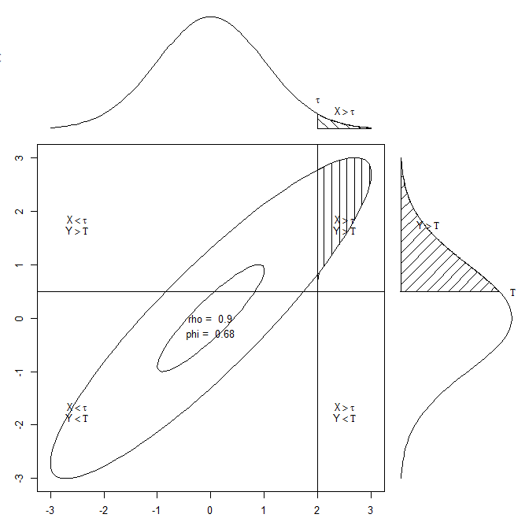

```r
draw.tetra(.9,2,0.5)
```

Asi se veria una correlación tetrachorica *debil*

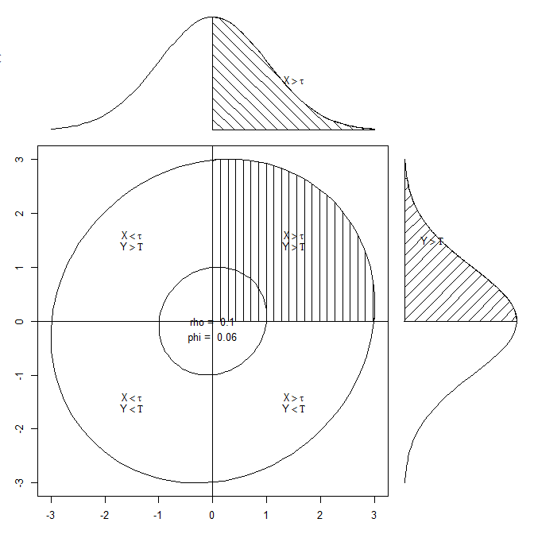

```r
draw.tetra(.1,0,0)
```

## Ejemplo

```r
library(ggplot2)
```

Se utilizará la base de datos *diamonds* del paquete *ggplot2*. Esta base cuenta con el precio y otros 9 atributos de aproximadamente 53,940 diamantes. Las variables son:

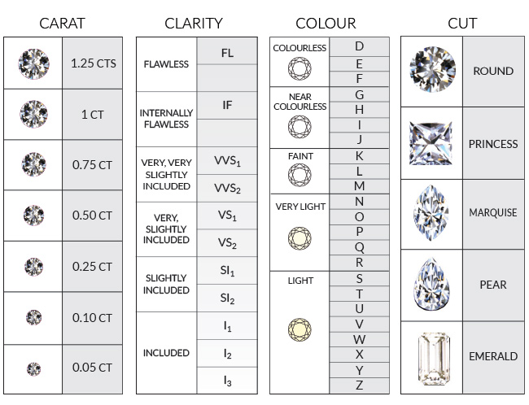

Primero cargarmos la base a un data frame.

Las variables cut, color y clarity son ordinales. Por lo tanto las convertimos en un *ordered factor*

```r
dfOrd  <- data.frame(diamonds)
head(dfOrd)
```

```
##   carat       cut color clarity depth table price    x    y    z
## 1  0.23     Ideal     E     SI2  61.5    55   326 3.95 3.98 2.43
## 2  0.21   Premium     E     SI1  59.8    61   326 3.89 3.84 2.31
## 3  0.23      Good     E     VS1  56.9    65   327 4.05 4.07 2.31
## 4  0.29   Premium     I     VS2  62.4    58   334 4.20 4.23 2.63
## 5  0.31      Good     J     SI2  63.3    58   335 4.34 4.35 2.75
## 6  0.24 Very Good     J    VVS2  62.8    57   336 3.94 3.96 2.48
```

Este conjunto de datos es de particular interés en R ya que permite realizar predicciones respecto al precio de un diamante en función de variables continuas y ordinales con más de 5 categorias. Para entender un poco el conjunto de datos incluimos la variación del precio en función de la raiz cubica de los kilates de la piedra dependiendo de su claridad, corte y su color.

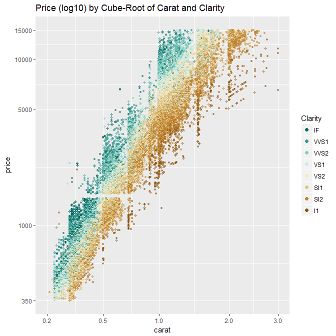

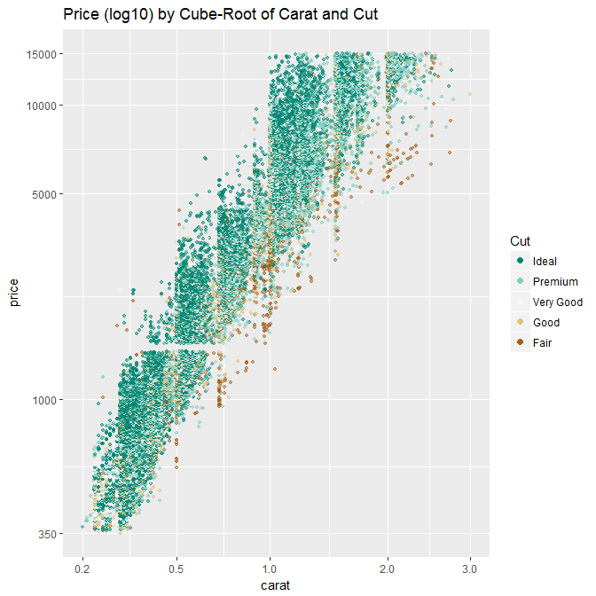

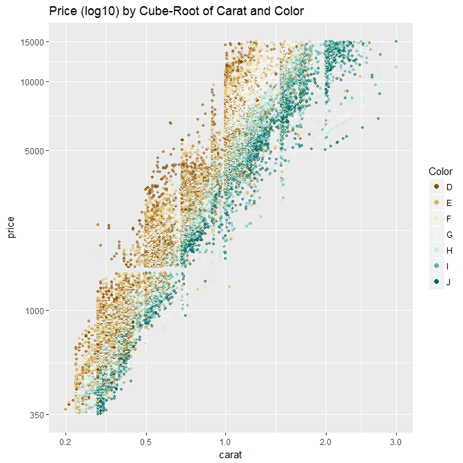

Posteriormente cambiamos las categorías de las variables ordinales a números consecutivos comenzando desde 1.

```r
ordNum <- data.matrix(dfOrd)
head(ordNum)
```

```
##      carat cut color clarity depth table price    x    y    z
## [1,]  0.23   5     2       2  61.5    55   326 3.95 3.98 2.43
## [2,]  0.21   4     2       3  59.8    61   326 3.89 3.84 2.31
## [3,]  0.23   2     2       5  56.9    65   327 4.05 4.07 2.31
## [4,]  0.29   4     6       4  62.4    58   334 4.20 4.23 2.63
## [5,]  0.31   2     7       2  63.3    58   335 4.34 4.35 2.75
## [6,]  0.24   3     7       6  62.8    57   336 3.94 3.96 2.48
```

Podemos comparar los resultados de aplicar la correlación de Pearson como si los datos ordinales fueran en realidad de intervalo con los resultados de buscar la $\rho$ que mejor describe la elipse de los datos.Los resultados son los siguientes:

Por lo general la correlación de Pearson tiende a subestimar la correlación entre variables ordinales.

```r
cor(ordNum[,2],ordNum[,3])
```

```
## [1] -0.02051852
```

```r
prop.table(table(ordNum[,2],ordNum[,3]))
```

```
##
##               1           2           3           4           5
##   1 0.003021876 0.004152762 0.005784205 0.005821283 0.005617353
##   2 0.012272896 0.017296997 0.016852058 0.016147571 0.013014461
##   3 0.028049685 0.044493882 0.040118650 0.042621431 0.033815350
##   4 0.029718205 0.043325918 0.043214683 0.054208380 0.043752317
##   5 0.052539859 0.072358176 0.070930664 0.090545050 0.057749351
##
##               6           7
##   1 0.003244346 0.002206155
##   2 0.009677419 0.005691509
##   3 0.022321098 0.012569522
##   4 0.026473860 0.014979607
##   5 0.038802373 0.016611049
```

```r
polychoric(ordNum[,c(2,3)])
```

```
## Call: polychoric(x = ordNum[, c(2, 3)])
## Polychoric correlations
##       cut   color
## cut    1.00
## color -0.03  1.00
##
##  with tau of
##          1    2     3    4   5   6
## cut   -1.9 -1.2 -0.40 0.25 Inf Inf
## color -1.1 -0.5 -0.04 0.51   1 1.6
```

Calculamos la matriz de correlaciones de las variables utilizando la función mixed.cor.

```r
pc <- mixed.cor(x=ordNum,smooth=TRUE, correct=TRUE)
```

```r
pc
```

```
## Call: mixed.cor(x = ordNum, smooth = TRUE, correct = TRUE)
##         carat cut   color clrty depth table price x     y     z
## carat    1.00
## cut     -0.15  1.00
## color    0.30 -0.03  1.00
## clarity -0.37  0.23  0.04  1.00
## depth    0.03 -0.24  0.05 -0.07  1.00
## table    0.18 -0.47  0.03 -0.17 -0.30  1.00
## price    0.92 -0.06  0.18 -0.15 -0.01  0.13  1.00
## x        0.98 -0.14  0.28 -0.39 -0.03  0.20  0.88  1.00
## y        0.95 -0.13  0.27 -0.37 -0.03  0.18  0.87  0.97  1.00
## z        0.95 -0.16  0.28 -0.38  0.09  0.15  0.86  0.97  0.95  1.00
```

## Análisis de componentes principales

Calculamos los primeros 5 componentes principales para la matriz anterior.

```r
faPC <- principal(r=pc$rho, nfactors=5, rotate="none",scores=TRUE)
```

```r
faPC
```

```
## Principal Components Analysis
## Call: principal(r = pc$rho, nfactors = 5, rotate = "none", scores = TRUE)
## Standardized loadings (pattern matrix) based upon correlation matrix
##           PC1   PC2   PC3   PC4   PC5   h2     u2 com
## carat    0.99  0.08  0.00 -0.01  0.04 0.98 0.0207 1.0
## cut     -0.21  0.80  0.35 -0.21 -0.20 0.88 0.1159 1.8
## color    0.31  0.18 -0.06  0.82 -0.44 1.00 0.0017 2.0
## clarity -0.42  0.37  0.22  0.48  0.63 0.99 0.0069 3.7
## depth    0.02  0.06 -0.95  0.06  0.16 0.93 0.0726 1.1
## table    0.24 -0.78  0.39  0.19  0.08 0.87 0.1275 1.9
## price    0.90  0.19  0.09 -0.03  0.27 0.93 0.0721 1.3
## x        0.99  0.07  0.05 -0.04  0.01 0.98 0.0176 1.0
## y        0.97  0.07  0.05 -0.04  0.01 0.96 0.0438 1.0
## z        0.97  0.08 -0.07 -0.03  0.03 0.96 0.0403 1.0
##
##                        PC1  PC2  PC3  PC4  PC5
## SS loadings           5.03 1.48 1.24 0.99 0.74
## Proportion Var        0.50 0.15 0.12 0.10 0.07
## Cumulative Var        0.50 0.65 0.77 0.87 0.95
## Proportion Explained  0.53 0.16 0.13 0.10 0.08
## Cumulative Proportion 0.53 0.69 0.82 0.92 1.00
##
## Mean item complexity =  1.6
## Test of the hypothesis that 5 components are sufficient.
##
## The root mean square of the residuals (RMSR) is  0.03
##
## Fit based upon off diagonal values = 1
```

Para encontrar la representación de alguna observación en las nuevas coordenadas podemos utilizar la función predict.

```r
predict(faPC,ordNum[1,],ordNum)
```

```
##            PC1       PC2        PC3       PC4       PC5
## [1,] -1.359591 0.2766684 -0.2198204 -1.596005 -1.426306
```

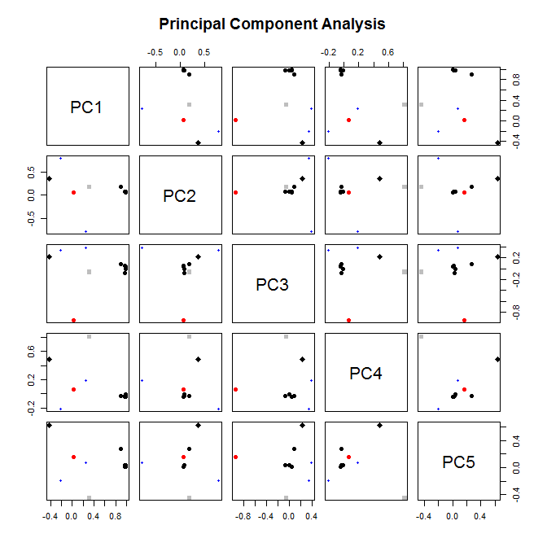

```r
fa.plot(faPC)
```

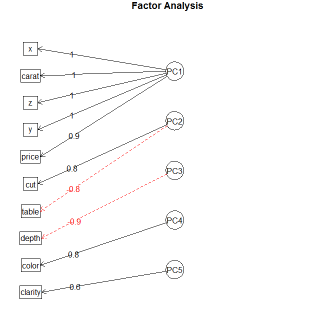

```r
fa.diagram(faPC)
```

Para determinar que variables contribuyen a cada una de las componentes principales podemos utilizar un Biplot. Les proponemos nombrar cada una de las componentes en base a estas variables.

- **Componente 1**: Correlación positiva x, y, z y carat –> Tamaño de la piedra
- **Componente 2**: Correlación positica corte y negativa a tabla –> Tamaño de la piedra –> Finesa
- **Componente 3**: Correlación positiva tabla y negativa a profundidad –> Tamaño de la piedra –> Forma de la piedra
- **Componente 4**: Correlación positiva color y claridad –> Tamaño de la piedra –> Pureza de la piedra
- **Componente 5**: Correlación positiva claridad y negativa a color –> Irridescencia de la piedra

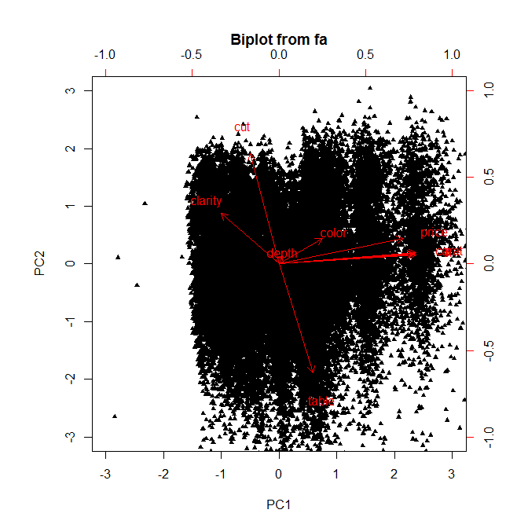

```r
faPC$scores <- psych::factor.scores(ordNum,faPC)
biplot.psych(faPC,choose=c(1,2),main = "Componente 1 vs Componente 2")
```

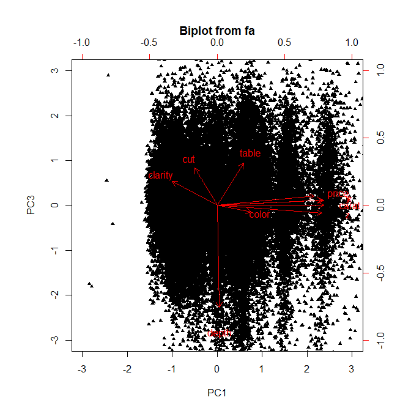

```r
biplot.psych(faPC,choose=c(1,3),main = "Componente 1 vs Componente 3")
```

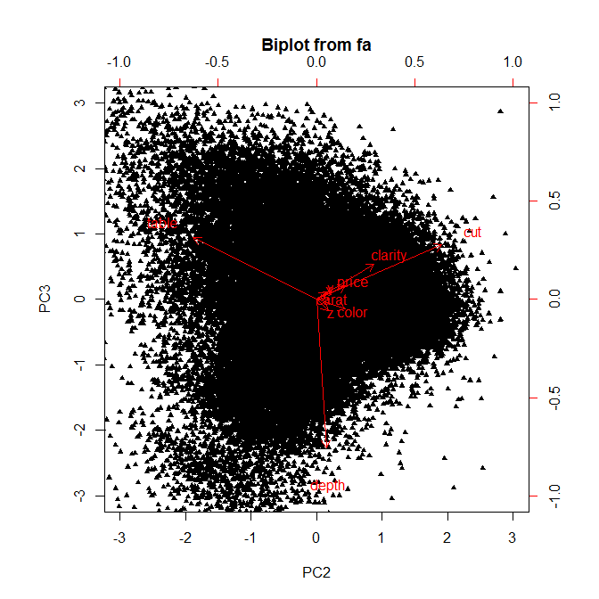

```r
biplot.psych(faPC,choose=c(2,3),main = "Componente 2 vs Componente 3")
```

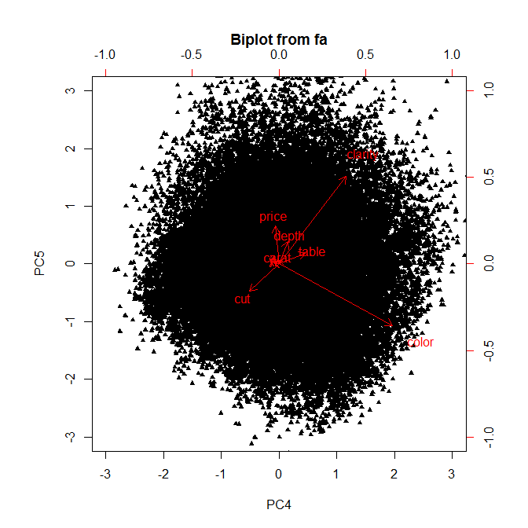

```r
biplot.psych(faPC,choose=c(4,5),main = "Componente 4 vs Componente 5")
```

## Referencias

- Olsson, U., Drasgow, F., & Dorans, N. J. (1982). *The polyserial correlation coefficient*. Psychometrika, 47(3), 337-347.
- Rodíguez, M.E., Álvarez, S., Bravo, E. (2001). *Coeficientes de asociación.* Universidad Autónoma Metropolitana.
- Uebersax JS. *The tetrachoric and polychoric correlation coefficients.* Statistical Methods for Rater Agreement. Web, accessed <18-02-2017>.